# SPSSOutput_Homework6Key_2018

[output not shown]

Log  
Log - Log - December 14, 2018

GET  
FILE='C:\MyGithub\N736Fall2017_Homework6Key\helpmkh.sav'.  
DATASET NAME DataSet1 WINDOW=FRONT.  
* Encoding: UTF-8.  
* ==================================  
* Homework 06 - logistic regression  
* ANSWER KEY 2018  
*  
* Melinda Higgins, PhD  
* dated 12/14/2018  
* ==================================  
* ============================================  
* For this homework we'll use the helpmkh dataset  
*  
* You will be working with the e2b variable  
* Number of times in past 6 months entered a  
* detox program (collected at Baseline)  
*  
* For this logistic regression homework 6,  
* I've provided the code below to capture the  
* individuals who did NOT say they had entered a detox  
* program in the 6 months preceeding baseline  
* ============================================  
* in SPSS use the MISSING() function to create  
* a logical expression to capture the individuals  
* who did NOT say they had entered a detox program  
* prior to baseline. The TRUE's are coded 1 and  
* FALSE's are coded 0.  
COMPUTE nodetox=MISSING(e2b).  
EXECUTE.  
* check the results using frequencies  
* the number of system-missing for e2b  
* should equal the number of 1's or TRUE's  
* for the new variable nodetox.  
FREQUENCIES VARIABLES=e2b nodetox  
/ORDER=ANALYSIS.

Frequencies  
Frequencies - Active Dataset - December 14, 2018

[DataSet1] C:\MyGithub\N736Fall2017_Homework6Key\helpmkh.sav

Frequencies  
Frequencies - Statistics - December 14, 2018

StatisticsStatistics, table, 1 levels of column headers and 2 levels of row headers, table with 4 columns and 4 rows

|  |  | e2b Number of times in past 6 months entered a detox program - Baseline | nodetox |
| --- | --- | --- | --- |
| N | Valid | 214 | 453 |
|  | Missing | 239 | 0 |

Frequency Table  
Frequency Table - e2b Number of times in past 6 months entered a detox program - Baseline - December(more) 14, 2018(less)

e2b Number of times in past 6 months entered a detox program - Baselinee2b Number of times in past 6 months entered a detox program - Baseline, table, 1 levels of column headers and 2 levels of row headers, table with 6 columns and 17 rows

|  |  | Frequency | Percent | Valid Percent | Cumulative Percent |
| --- | --- | --- | --- | --- | --- |
| Valid | 1 | 90 | 19.9 | 42.1 | 42.1 |
|  | 2 | 57 | 12.6 | 26.6 | 68.7 |
|  | 3 | 29 | 6.4 | 13.6 | 82.2 |
|  | 4 | 16 | 3.5 | 7.5 | 89.7 |
|  | 5 | 6 | 1.3 | 2.8 | 92.5 |
|  | 6 | 4 | .9 | 1.9 | 94.4 |
|  | 7 | 3 | .7 | 1.4 | 95.8 |
|  | 8 | 4 | .9 | 1.9 | 97.7 |
|  | 11 | 2 | .4 | .9 | 98.6 |
|  | 14 | 1 | .2 | .5 | 99.1 |
|  | 17 | 1 | .2 | .5 | 99.5 |
|  | 21 | 1 | .2 | .5 | 100.0 |
|  | Total | 214 | 47.2 | 100.0 |  |
| Missing | System | 239 | 52.8 |  |  |
| Total |  | 453 | 100.0 |  |  |

Frequency Table  
Frequency Table - nodetox - December 14, 2018

nodetoxnodetox, table, 1 levels of column headers and 2 levels of row headers, table with 6 columns and 5 rows

|  |  | Frequency | Percent | Valid Percent | Cumulative Percent |
| --- | --- | --- | --- | --- | --- |
| Valid | .00 | 214 | 47.2 | 47.2 | 47.2 |
|  | 1.00 | 239 | 52.8 | 52.8 | 100.0 |
|  | Total | 453 | 100.0 | 100.0 |  |

Log  
Log - Log - December 14, 2018

* MODEL 1  
* Consider the continuous variable mcs as a predictor for nodetox  
* run a logistic regression of the probability of not  
* being in a detox program prior to baseline (nodetox)  
* given their mental health scores (mcs)  
* make a plot of the the predicted probability of no detox (nodetox)  
* by the mental health scores (mcs)  
* what value of the mcs leads to a probability of not  
* being in a detox program => 0.5? (hint: use the  
* plot you just made).  
* ============================================.  
* Logistic regression of mcs to predict  
* the probability of being nodetox (not being in detox)  
* we'll also SAVE the predicted probabilities  
* and the predicted group membership  
*  
* NOTE: The current default threshold cutoff is 0.5.  
* ============================================.  
LOGISTIC REGRESSION VARIABLES nodetox  
/METHOD=ENTER mcs  
/SAVE=PRED PGROUP  
/PRINT=GOODFIT ITER(1) CI(95)  
/CRITERIA=PIN(0.05) POUT(0.10) ITERATE(20) CUT(0.5).

Logistic Regression  
Logistic Regression - Case Processing Summary - December 14, 2018

Case Processing SummaryCase Processing Summary, table, 1 levels of column headers and 2 levels of row headers, table with 4 columns and 8 rows

| Unweighted Cases<sup>a</sup> |  | N | Percent |
| --- | --- | --- | --- |
| Selected Cases | Included in Analysis | 453 | 100.0 |
|  | Missing Cases | 0 | .0 |
|  | Total | 453 | 100.0 |
| Unselected Cases |  | 0 | .0 |
| Total |  | 453 | 100.0 |

a. If weight is in effect, see classification table for the total number of cases.

Logistic Regression  
Logistic Regression - Dependent Variable Encoding - December 14, 2018

Dependent Variable EncodingDependent Variable Encoding, table, 1 levels of column headers and 1 levels of row headers, table with 2 columns and 4 rows

| Original Value | Internal Value |
| --- | --- |
| .00 | 0 |
| 1.00 | 1 |

Block 0: Beginning Block  
Block 0: Beginning Block - Iteration History - December 14, 2018

Iteration History<sup>a,b,c</sup>Iteration History, table, 2 levels of column headers and 2 levels of row headers, table with 4 columns and 8 rows

| Iteration |  | -2 Log likelihood | Coefficients |
| --- | --- | --- | --- |
|  |  |  | Constant |
| Step 0 | 1 | 626.611 | .110 |
|  | 2 | 626.611 | .110 |

a. Constant is included in the model.  
b. Initial -2 Log Likelihood: 626.611  
c. Estimation terminated at iteration number 2 because parameter estimates changed by less than .001.

Block 0: Beginning Block  
Block 0: Beginning Block - Classification Table - December 14, 2018

Classification Table<sup>a,b</sup>Classification Table, table, 3 levels of column headers and 3 levels of row headers, table with 6 columns and 9 rows

|  | Observed |  | Predicted |  |  |  |
| --- | --- | --- | --- | --- | --- | --- |
|  |  |  | nodetox |  | Percentage Correct |  |
|  |  |  | .00 | 1.00 |  |  |
| Step 0 | nodetox | .00 | 0 | 214 |  | .0 |
|  |  | 1.00 | 0 | 239 | 100.0 |  |
|  | Overall Percentage |  |  |  | 52.8 |  |

a. Constant is included in the model.  
b. The cut value is .500

Block 0: Beginning Block  
Block 0: Beginning Block - Variables in the Equation - December 14, 2018

Variables in the EquationVariables in the Equation, table, 1 levels of column headers and 2 levels of row headers, table with 8 columns and 3 rows

|  |  | B | S.E. | Wald | df | Sig. | Exp(B) |
| --- | --- | --- | --- | --- | --- | --- | --- |
| Step 0 | Constant | .110 | .094 | 1.378 | 1 | .240 | 1.117 |

Block 0: Beginning Block  
Block 0: Beginning Block - Variables not in the Equation - December 14, 2018

Variables not in the EquationVariables not in the Equation, table, 1 levels of column headers and 3 levels of row headers, table with 6 columns and 4 rows

|  |  |  | Score | df | Sig. |
| --- | --- | --- | --- | --- | --- |
| Step 0 | Variables | SF36 Mental Composite Score - Baseline | 24.324 | 1 | .000 |
|  | Overall Statistics |  | 24.324 | 1 | .000 |

Block 1: Method = Enter  
Block 1: Method = Enter - Iteration History - December 14, 2018

Iteration History<sup>a,b,c,d</sup>Iteration History, table, 2 levels of column headers and 2 levels of row headers, table with 5 columns and 10 rows

| Iteration |  | -2 Log likelihood | Coefficients |  |
| --- | --- | --- | --- | --- |
|  |  |  | Constant | SF36 Mental Composite Score - Baseline |
| Step 1 | 1 | 601.719 | -1.033 | .036 |
|  | 2 | 601.646 | -1.084 | .038 |
|  | 3 | 601.646 | -1.085 | .038 |

a. Method: Enter  
b. Constant is included in the model.  
c. Initial -2 Log Likelihood: 626.611  
d. Estimation terminated at iteration number 3 because parameter estimates changed by less than .001.

Block 1: Method = Enter  
Block 1: Method = Enter - Omnibus Tests of Model Coefficients - December 14, 2018

Omnibus Tests of Model CoefficientsOmnibus Tests of Model Coefficients, table, 1 levels of column headers and 2 levels of row headers, table with 5 columns and 5 rows

|  |  | Chi-square | df | Sig. |
| --- | --- | --- | --- | --- |
| Step 1 | Step | 24.965 | 1 | .000 |
|  | Block | 24.965 | 1 | .000 |
|  | Model | 24.965 | 1 | .000 |

Block 1: Method = Enter  
Block 1: Method = Enter - Model Summary - December 14, 2018

Model SummaryModel Summary, table, 1 levels of column headers and 1 levels of row headers, table with 4 columns and 4 rows

| Step | -2 Log likelihood | Cox & Snell R Square | Nagelkerke R Square |
| --- | --- | --- | --- |
| 1 | 601.646<sup>a</sup> | .054 | .072 |

a. Estimation terminated at iteration number 3 because parameter estimates changed by less than .001.

Block 1: Method = Enter  
Block 1: Method = Enter - Hosmer and Lemeshow Test - December 14, 2018

Hosmer and Lemeshow TestHosmer and Lemeshow Test, table, 1 levels of column headers and 1 levels of row headers, table with 4 columns and 3 rows

| Step | Chi-square | df | Sig. |
| --- | --- | --- | --- |
| 1 | 14.844 | 8 | .062 |

Block 1: Method = Enter  
Block 1: Method = Enter - Contingency Table for Hosmer and Lemeshow Test - December 14, 2018

Contingency Table for Hosmer and Lemeshow TestContingency Table for Hosmer and Lemeshow Test, table, 2 levels of column headers and 2 levels of row headers, table with 7 columns and 13 rows

|  |  | nodetox = .00 |  | nodetox = 1.00 |  | Total |  |
| --- | --- | --- | --- | --- | --- | --- | --- |
|  |  | Observed | Expected | Observed | Expected |  |  |
| Step 1 | 1 | 21 | 28.702 | 24 | 16.298 |  | 45 |
|  | 2 | 26 | 26.771 | 19 | 18.229 | 45 |  |
|  | 3 | 26 | 25.424 | 19 | 19.576 | 45 |  |
|  | 4 | 24 | 24.154 | 21 | 20.846 | 45 |  |
|  | 5 | 28 | 22.939 | 17 | 22.061 | 45 |  |
|  | 6 | 29 | 21.625 | 16 | 23.375 | 45 |  |
|  | 7 | 21 | 19.519 | 24 | 25.481 | 45 |  |
|  | 8 | 17 | 17.391 | 28 | 27.609 | 45 |  |
|  | 9 | 13 | 14.968 | 32 | 30.032 | 45 |  |
|  | 10 | 9 | 12.507 | 39 | 35.493 | 48 |  |

Block 1: Method = Enter  
Block 1: Method = Enter - Classification Table - December 14, 2018

Classification Table<sup>a</sup>Classification Table, table, 3 levels of column headers and 3 levels of row headers, table with 6 columns and 8 rows

|  | Observed |  | Predicted |  |  |  |
| --- | --- | --- | --- | --- | --- | --- |
|  |  |  | nodetox |  | Percentage Correct |  |
|  |  |  | .00 | 1.00 |  |  |
| Step 1 | nodetox | .00 | 122 | 92 |  | 57.0 |
|  |  | 1.00 | 100 | 139 | 58.2 |  |
|  | Overall Percentage |  |  |  | 57.6 |  |

a. The cut value is .500

Block 1: Method = Enter  
Block 1: Method = Enter - Variables in the Equation - December 14, 2018

Variables in the EquationVariables in the Equation, table, 2 levels of column headers and 2 levels of row headers, table with 10 columns and 6 rows

|  |  | B | S.E. | Wald | df | Sig. | Exp(B) | 95% C.I.for EXP(B) |  |
| --- | --- | --- | --- | --- | --- | --- | --- | --- | --- |
|  |  |  |  |  |  |  |  | Lower | Upper |
| Step 1<sup>a</sup> | SF36 Mental Composite Score - Baseline | .038 | .008 | 23.274 | 1 | .000 | 1.039 | 1.023 | 1.055 |
|  | Constant | -1.085 | .263 | 16.981 | 1 | .000 | .338 |  |  |

a. Variable(s) entered on step 1: SF36 Mental Composite Score - Baseline.

Log  
Log - Log - December 14, 2018

* ============================================.  
* plot the predicted probability of nodetox  
* against mcs to see the effect of mcs scores  
* with the predicted probability  
* ============================================.  
GRAPH  
/SCATTERPLOT(BIVAR)=mcs WITH PRE_1  
/MISSING=LISTWISE.

Graph  
Graph - Scatter of PRE_1 mcs - December 14, 2018

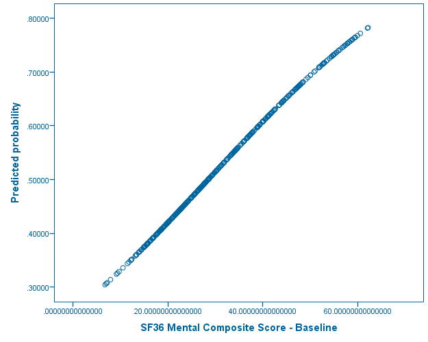


Log  
Log - Log - December 14, 2018

* UPDATE - OPTIONAL for Homework 6 - Model 1  
* The code below shows the ROC curve for the  
* model results captured by PRE_1  
* for the outcome nodetox (with an "event"  
* defined as when nodetox=1).  
* This will give you the AUC (area under the curve)  
* for the model (albeit with 1 predictor, mcs here).  
* The AUC's match since there is only 1  
* continuous predictor for this model.  
ROC PRE_1 BY nodetox (1)  
/PLOT=CURVE(REFERENCE)  
/PRINT=SE COORDINATES  
/CRITERIA=CUTOFF(INCLUDE) TESTPOS(LARGE) DISTRIBUTION(FREE) CI(95)  
/MISSING=EXCLUDE.

ROC Curve  
ROC Curve - Case Processing Summary - December 14, 2018

Case Processing SummaryCase Processing Summary, table, 1 levels of column headers and 1 levels of row headers, table with 2 columns and 6 rows

| nodetox | Valid N (listwise) |
| --- | --- |
| Positive<sup>a</sup> | 239 |
| Negative | 214 |

Larger values of the test result variable(s) indicate stronger evidence for a positive actual state.  
a. The positive actual state is 1.00.

ROC Curve  
ROC Curve - ROC Curve - December 14, 2018

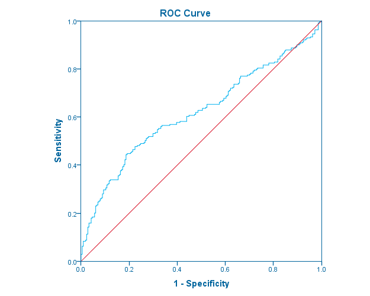

ROC Curve  
ROC Curve - Area Under the Curve - December 14, 2018

Area Under the CurveArea Under the Curve, table, Test Result Variable(s), PRE_1 Predicted probability, 1 layers, 2 levels of column headers and 0 levels of row headers, table with 5 columns and 7 rows

| PRE_1 Predicted probability PRE_1 Predicted probability |  |  |  |  |
| --- | --- | --- | --- | --- |
| Area | Std. Error<sup>a</sup> | Asymptotic Sig.<sup>b</sup> | Asymptotic 95% Confidence Interval |  |
|  |  |  | Lower Bound | Upper Bound |
| .619 | .026 | .000 | .567 | .671 |

a. Under the nonparametric assumption  
b. Null hypothesis: true area = 0.5

ROC Curve  
ROC Curve - Coordinates of the Curve - December 14, 2018

Coordinates of the CurveCoordinates of the Curve, table, Test Result Variable(s), PRE_1 Predicted probability, 1 layers, 1 levels of column headers and 0 levels of row headers, table with 3 columns and 458 rows

| PRE_1 Predicted probability PRE_1 Predicted probability |  |  |
| --- | --- | --- |
| Positive if Greater Than or Equal To<sup>a</sup> | Sensitivity | 1 - Specificity |
| .0000000 | 1.000 | 1.000 |
| .3053521 | .996 | 1.000 |
| .3072266 | .996 | .995 |
| .3109031 | .996 | .991 |
| .3188570 | .992 | .991 |
| .3249355 | .992 | .986 |
| .3273288 | .987 | .986 |
| .3322094 | .983 | .986 |
| .3397150 | .979 | .986 |
| .3450800 | .975 | .986 |
| .3481164 | .971 | .986 |
| .3502970 | .967 | .986 |
| .3512881 | .962 | .986 |
| .3548197 | .962 | .981 |
| .3586565 | .962 | .977 |
| .3597406 | .962 | .972 |
| .3601786 | .958 | .972 |
| .3622483 | .954 | .972 |
| .3646952 | .950 | .972 |
| .3658239 | .946 | .972 |
| .3675487 | .946 | .967 |
| .3689048 | .946 | .963 |
| .3694445 | .941 | .963 |
| .3715614 | .937 | .963 |
| .3734872 | .933 | .963 |
| .3736102 | .933 | .958 |
| .3743454 | .933 | .953 |
| .3751576 | .929 | .953 |
| .3756826 | .929 | .949 |

[output cut: 427 more lines]

Log  
Log - Log - December 14, 2018

Regression  
Regression - Variables Entered/Removed - December 14, 2018

Variables Entered/Removed<sup>a</sup>Variables Entered/Removed, table, 1 levels of column headers and 1 levels of row headers, table with 4 columns and 5 rows

| Model | Variables Entered | Variables Removed | Method |
| --- | --- | --- | --- |
| 1 | cesd CESD total score - Baseline, age Age at baseline (in years), female Gender of respondent, pss_fr Perceived Social Support - friends, pcs SF36 Physical Composite Score - Baseline, mcs SF36 Mental … | . | Enter |

a. Dependent Variable: nodetox  
b. All requested variables entered.

Regression  
Regression - Coefficients - December 14, 2018

Coefficients<sup>a</sup>Coefficients, table, 2 levels of column headers and 2 levels of row headers, table with 4 columns and 10 rows

| Model |  | Collinearity Statistics |  |
| --- | --- | --- | --- |
|  |  | Tolerance | VIF |
| 1 | age Age at baseline (in years) | .935 | 1.070 |
|  | female Gender of respondent | .945 | 1.058 |
|  | pss_fr Perceived Social Support - friends | .947 | 1.056 |
|  | pcs SF36 Physical Composite Score - Baseline | .840 | 1.191 |
|  | mcs SF36 Mental Composite Score - Baseline | .525 | 1.904 |
|  | cesd CESD total score - Baseline | .475 | 2.104 |

a. Dependent Variable: nodetox

Regression  
Regression - Collinearity Diagnostics - December 14, 2018

Collinearity Diagnostics<sup>a</sup>Collinearity Diagnostics, table, 2 levels of column headers and 2 levels of row headers, table with 11 columns and 11 rows

| Model | Dimension | Eigenvalue | Condition Index | Variance Proportions |  |  |  |  |  |  |
| --- | --- | --- | --- | --- | --- | --- | --- | --- | --- | --- |
|  |  |  |  | (Constant) | age Age at baseline (in years) | female Gender of respondent | pss_fr Perceived Social Support - friends | pcs SF36 Physical Composite Score - Baseline | mcs SF36 Mental Composite Score - Baseline | cesd CESD total score - Baseline |
| 1 | 1 | 5.716 | 1.000 | .00 | .00 | .01 | .01 | .00 | .00 | .00 |
|  | 2 | .738 | 2.783 | .00 | .00 | .90 | .00 | .00 | .00 | .00 |
|  | 3 | .255 | 4.731 | .00 | .00 | .02 | .46 | .00 | .03 | .09 |
|  | 4 | .186 | 5.548 | .00 | .00 | .05 | .50 | .00 | .17 | .05 |
|  | 5 | .058 | 9.928 | .00 | .16 | .02 | .00 | .47 | .09 | .03 |
|  | 6 | .040 | 11.980 | .00 | .56 | .00 | .02 | .03 | .38 | .34 |
|  | 7 | .007 | 29.126 | 1.00 | .27 | .00 | .01 | .49 | .33 | .49 |

a. Dependent Variable: nodetox

Log  
Log - Log - December 14, 2018

* ============================================.  
* put all variables together  
* and run a multivariate logistic regression  
* UPDATE add /SAVE=PRED PGROUP to save model fit results  
* ============================================.  
LOGISTIC REGRESSION VARIABLES nodetox  
/METHOD=ENTER age female pss_fr pcs mcs cesd  
/SAVE=PRED PGROUP  
/PRINT=GOODFIT ITER(1) CI(95)  
/CRITERIA=PIN(0.05) POUT(0.10) ITERATE(20) CUT(0.5).

Logistic Regression  
Logistic Regression - Case Processing Summary - December 14, 2018

Case Processing SummaryCase Processing Summary, table, 1 levels of column headers and 2 levels of row headers, table with 4 columns and 8 rows

| Unweighted Cases<sup>a</sup> |  | N | Percent |
| --- | --- | --- | --- |
| Selected Cases | Included in Analysis | 453 | 100.0 |
|  | Missing Cases | 0 | .0 |
|  | Total | 453 | 100.0 |
| Unselected Cases |  | 0 | .0 |
| Total |  | 453 | 100.0 |

a. If weight is in effect, see classification table for the total number of cases.

Logistic Regression  
Logistic Regression - Dependent Variable Encoding - December 14, 2018

Dependent Variable EncodingDependent Variable Encoding, table, 1 levels of column headers and 1 levels of row headers, table with 2 columns and 4 rows

| Original Value | Internal Value |
| --- | --- |
| .00 | 0 |
| 1.00 | 1 |

Block 0: Beginning Block  
Block 0: Beginning Block - Iteration History - December 14, 2018

Iteration History<sup>a,b,c</sup>Iteration History, table, 2 levels of column headers and 2 levels of row headers, table with 4 columns and 8 rows

| Iteration |  | -2 Log likelihood | Coefficients |
| --- | --- | --- | --- |
|  |  |  | Constant |
| Step 0 | 1 | 626.611 | .110 |
|  | 2 | 626.611 | .110 |

a. Constant is included in the model.  
b. Initial -2 Log Likelihood: 626.611  
c. Estimation terminated at iteration number 2 because parameter estimates changed by less than .001.

Block 0: Beginning Block  
Block 0: Beginning Block - Classification Table - December 14, 2018

Classification Table<sup>a,b</sup>Classification Table, table, 3 levels of column headers and 3 levels of row headers, table with 6 columns and 9 rows

|  | Observed |  | Predicted |  |  |  |
| --- | --- | --- | --- | --- | --- | --- |
|  |  |  | nodetox |  | Percentage Correct |  |
|  |  |  | .00 | 1.00 |  |  |
| Step 0 | nodetox | .00 | 0 | 214 |  | .0 |
|  |  | 1.00 | 0 | 239 | 100.0 |  |
|  | Overall Percentage |  |  |  | 52.8 |  |

a. Constant is included in the model.  
b. The cut value is .500

Block 0: Beginning Block  
Block 0: Beginning Block - Variables in the Equation - December 14, 2018

Variables in the EquationVariables in the Equation, table, 1 levels of column headers and 2 levels of row headers, table with 8 columns and 3 rows

|  |  | B | S.E. | Wald | df | Sig. | Exp(B) |
| --- | --- | --- | --- | --- | --- | --- | --- |
| Step 0 | Constant | .110 | .094 | 1.378 | 1 | .240 | 1.117 |

Block 0: Beginning Block  
Block 0: Beginning Block - Variables not in the Equation - December 14, 2018

Variables not in the EquationVariables not in the Equation, table, 1 levels of column headers and 3 levels of row headers, table with 6 columns and 9 rows

|  |  |  | Score | df | Sig. |
| --- | --- | --- | --- | --- | --- |
| Step 0 | Variables | Age at baseline (in years) | .155 | 1 | .694 |
|  |  | Gender of respondent | 2.797 | 1 | .094 |
|  |  | Perceived Social Support - friends | 6.508 | 1 | .011 |
|  |  | SF36 Physical Composite Score - Baseline | 10.536 | 1 | .001 |
|  |  | SF36 Mental Composite Score - Baseline | 24.324 | 1 | .000 |
|  |  | CESD total score - Baseline | 19.971 | 1 | .000 |
|  | Overall Statistics |  | 41.872 | 6 | .000 |

Block 1: Method = Enter  
Block 1: Method = Enter - Iteration History - December 14, 2018

Iteration History<sup>a,b,c,d</sup>Iteration History, table, 2 levels of column headers and 2 levels of row headers, table with 10 columns and 11 rows

| Iteration |  | -2 Log likelihood | Coefficients |  |  |  |  |  |  |
| --- | --- | --- | --- | --- | --- | --- | --- | --- | --- |
|  |  |  | Constant | Age at baseline (in years) | Gender of respondent | Perceived Social Support - friends | SF36 Physical Composite Score - Baseline | SF36 Mental Composite Score - Baseline | CESD total score - Baseline |
| Step 1 | 1 | 583.084 | -1.942 | -.002 | .596 | .033 | .024 | .029 | -.009 |
|  | 2 | 582.727 | -2.111 | -.002 | .663 | .037 | .026 | .032 | -.010 |
|  | 3 | 582.726 | -2.115 | -.002 | .665 | .037 | .026 | .032 | -.010 |
|  | 4 | 582.726 | -2.115 | -.002 | .665 | .037 | .026 | .032 | -.010 |

a. Method: Enter  
b. Constant is included in the model.  
c. Initial -2 Log Likelihood: 626.611  
d. Estimation terminated at iteration number 4 because parameter estimates changed by less than .001.

Block 1: Method = Enter  
Block 1: Method = Enter - Omnibus Tests of Model Coefficients - December 14, 2018

Omnibus Tests of Model CoefficientsOmnibus Tests of Model Coefficients, table, 1 levels of column headers and 2 levels of row headers, table with 5 columns and 5 rows

|  |  | Chi-square | df | Sig. |
| --- | --- | --- | --- | --- |
| Step 1 | Step | 43.885 | 6 | .000 |
|  | Block | 43.885 | 6 | .000 |
|  | Model | 43.885 | 6 | .000 |

Block 1: Method = Enter  
Block 1: Method = Enter - Model Summary - December 14, 2018

Model SummaryModel Summary, table, 1 levels of column headers and 1 levels of row headers, table with 4 columns and 4 rows

| Step | -2 Log likelihood | Cox & Snell R Square | Nagelkerke R Square |
| --- | --- | --- | --- |
| 1 | 582.726<sup>a</sup> | .092 | .123 |

a. Estimation terminated at iteration number 4 because parameter estimates changed by less than .001.

Block 1: Method = Enter  
Block 1: Method = Enter - Hosmer and Lemeshow Test - December 14, 2018

Hosmer and Lemeshow TestHosmer and Lemeshow Test, table, 1 levels of column headers and 1 levels of row headers, table with 4 columns and 3 rows

| Step | Chi-square | df | Sig. |
| --- | --- | --- | --- |
| 1 | 6.528 | 8 | .588 |

Block 1: Method = Enter  
Block 1: Method = Enter - Contingency Table for Hosmer and Lemeshow Test - December 14, 2018

Contingency Table for Hosmer and Lemeshow TestContingency Table for Hosmer and Lemeshow Test, table, 2 levels of column headers and 2 levels of row headers, table with 7 columns and 13 rows

|  |  | nodetox = .00 |  | nodetox = 1.00 |  | Total |  |
| --- | --- | --- | --- | --- | --- | --- | --- |
|  |  | Observed | Expected | Observed | Expected |  |  |
| Step 1 | 1 | 30 | 31.560 | 15 | 13.440 |  | 45 |
|  | 2 | 28 | 28.693 | 17 | 16.307 | 45 |  |
|  | 3 | 24 | 26.851 | 21 | 18.149 | 45 |  |
|  | 4 | 29 | 25.217 | 16 | 19.783 | 45 |  |
|  | 5 | 23 | 23.208 | 22 | 21.792 | 45 |  |
|  | 6 | 22 | 20.685 | 23 | 24.315 | 45 |  |
|  | 7 | 18 | 18.496 | 27 | 26.504 | 45 |  |
|  | 8 | 16 | 16.050 | 29 | 28.950 | 45 |  |
|  | 9 | 18 | 13.470 | 27 | 31.530 | 45 |  |
|  | 10 | 6 | 9.770 | 42 | 38.230 | 48 |  |

Block 1: Method = Enter  
Block 1: Method = Enter - Classification Table - December 14, 2018

Classification Table<sup>a</sup>Classification Table, table, 3 levels of column headers and 3 levels of row headers, table with 6 columns and 8 rows

|  | Observed |  | Predicted |  |  |  |
| --- | --- | --- | --- | --- | --- | --- |
|  |  |  | nodetox |  | Percentage Correct |  |
|  |  |  | .00 | 1.00 |  |  |
| Step 1 | nodetox | .00 | 131 | 83 |  | 61.2 |
|  |  | 1.00 | 89 | 150 | 62.8 |  |
|  | Overall Percentage |  |  |  | 62.0 |  |

a. The cut value is .500

Block 1: Method = Enter  
Block 1: Method = Enter - Variables in the Equation - December 14, 2018

Variables in the EquationVariables in the Equation, table, 2 levels of column headers and 2 levels of row headers, table with 10 columns and 11 rows

|  |  | B | S.E. | Wald | df | Sig. | Exp(B) | 95% C.I.for EXP(B) |  |
| --- | --- | --- | --- | --- | --- | --- | --- | --- | --- |
|  |  |  |  |  |  |  |  | Lower | Upper |
| Step 1<sup>a</sup> | Age at baseline (in years) | -.002 | .013 | .019 | 1 | .891 | .998 | .972 | 1.025 |
|  | Gender of respondent | .665 | .245 | 7.361 | 1 | .007 | 1.944 | 1.203 | 3.141 |
|  | Perceived Social Support - friends | .037 | .026 | 2.080 | 1 | .149 | 1.037 | .987 | 1.091 |
|  | SF36 Physical Composite Score - Baseline | .026 | .010 | 6.702 | 1 | .010 | 1.026 | 1.006 | 1.046 |
|  | SF36 Mental Composite Score - Baseline | .032 | .011 | 8.565 | 1 | .003 | 1.032 | 1.010 | 1.054 |
|  | CESD total score - Baseline | -.010 | .012 | .776 | 1 | .378 | .990 | .968 | 1.013 |
|  | Constant | -2.115 | 1.078 | 3.849 | 1 | .050 | .121 |  |  |

a. Variable(s) entered on step 1: Age at baseline (in years), Gender of respondent, Perceived Social Support - friends, SF36 Physical Composite Score - Baseline, SF36 Mental Composite Score - Baseline, CESD total score - Baseline.

Log  
Log - Log - December 14, 2018

ROC Curve  
ROC Curve - Case Processing Summary - December 14, 2018

Case Processing SummaryCase Processing Summary, table, 1 levels of column headers and 1 levels of row headers, table with 2 columns and 6 rows

| nodetox | Valid N (listwise) |
| --- | --- |
| Positive<sup>a</sup> | 239 |
| Negative | 214 |

Larger values of the test result variable(s) indicate stronger evidence for a positive actual state.  
a. The positive actual state is 1.00.

ROC Curve  
ROC Curve - ROC Curve - December 14, 2018

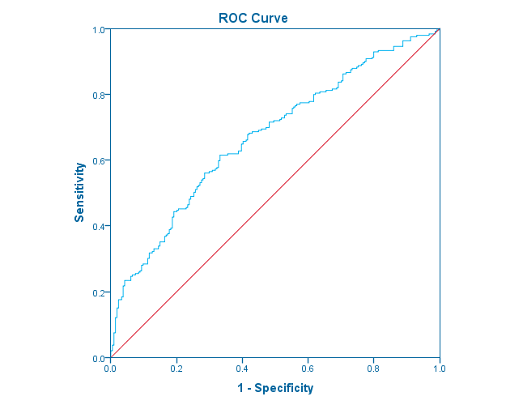

ROC Curve  
ROC Curve - Area Under the Curve - December 14, 2018

Area Under the CurveArea Under the Curve, table, Test Result Variable(s), PRE_2 Predicted probability, 1 layers, 2 levels of column headers and 0 levels of row headers, table with 5 columns and 7 rows

| PRE_2 Predicted probability PRE_2 Predicted probability |  |  |  |  |
| --- | --- | --- | --- | --- |
| Area | Std. Error<sup>a</sup> | Asymptotic Sig.<sup>b</sup> | Asymptotic 95% Confidence Interval |  |
|  |  |  | Lower Bound | Upper Bound |
| .670 | .025 | .000 | .621 | .719 |

a. Under the nonparametric assumption  
b. Null hypothesis: true area = 0.5

ROC Curve  
ROC Curve - Coordinates of the Curve - December 14, 2018

Coordinates of the CurveCoordinates of the Curve, table, Test Result Variable(s), PRE_2 Predicted probability, 1 layers, 1 levels of column headers and 0 levels of row headers, table with 3 columns and 458 rows

| PRE_2 Predicted probability PRE_2 Predicted probability |  |  |
| --- | --- | --- |
| Positive if Greater Than or Equal To<sup>a</sup> | Sensitivity | 1 - Specificity |
| .0000000 | 1.000 | 1.000 |
| .2428942 | .996 | 1.000 |
| .2520815 | .996 | .995 |
| .2585162 | .996 | .991 |
| .2626894 | .992 | .991 |
| .2679026 | .992 | .986 |
| .2729397 | .987 | .986 |
| .2758313 | .983 | .986 |
| .2785569 | .983 | .981 |
| .2810784 | .983 | .977 |
| .2823720 | .983 | .972 |
| .2840705 | .983 | .967 |
| .2846984 | .979 | .967 |
| .2853459 | .979 | .963 |
| .2873059 | .979 | .958 |
| .2905638 | .979 | .953 |
| .2927368 | .979 | .949 |
| .2933898 | .979 | .944 |
| .2947289 | .979 | .939 |
| .2956985 | .979 | .935 |
| .2961843 | .979 | .930 |
| .2979852 | .975 | .930 |
| .2995610 | .975 | .925 |
| .2999297 | .975 | .921 |
| .3008092 | .975 | .916 |
| .3016465 | .975 | .911 |
| .3025515 | .971 | .911 |
| .3038978 | .967 | .911 |
| .3046378 | .962 | .911 |

[output cut: 427 more lines]

[output not shown]

[output not shown]

Toolbar Buttons

[output not shown]

[output not shown]

[output not shown]

[output not shown]

[output not shown]

[output not shown]

[output not shown]